# Sales Dashboard - Comprehensive Analysis

Data Science Analysis

2025-09-07

# Introduction

This dashboard provides a comprehensive analysis of sales data using R and ggplot2. The analysis includes key performance indicators, trends, and visualizations to understand sales performance across different time periods and metrics.

## Problem Statement

Create a sales dashboard that provides insights into: - Overall sales performance - Sales trends over time - Order volume analysis - Product quantity patterns - Monthly and yearly performance metrics

## Dataset

# Data Loading and Understanding

```r
# Load required libraries
library(ggplot2)
library(dplyr)
library(lubridate)
library(scales)
library(gridExtra)
library(grid)

# Set theme for white background plots
theme_set(theme_minimal() +
          theme(panel.background = element_rect(fill = "white", color = NA),
                plot.background = element_rect(fill = "white", color = NA)))
```

```r
# Load the dataset
sales_data <- read.csv("sales-dataset/sales.csv")

# Display basic information about the dataset
cat("Dataset Information:\n")
```

```
## Dataset Information:
```

```r
cat("Shape:", nrow(sales_data), "rows,", ncol(sales_data), "columns\n")
```

```
## Shape: 5353 rows, 25 columns
```

```r
cat("Column names:", paste(names(sales_data), collapse = ", "), "\n")
```

```
## Column names: ORDERNUMBER, QUANTITYORDERED, PRICEEACH, ORDERLINENUMBER, SALES, ORDERDATE, STATUS, QTR_ID, MONTH_ID, YEAR_ID, PRODUCTLINE, MSRP, PRODUCTCODE, CUSTOMERNAME, PHONE, ADDRESSLINE1, ADDRESSLINE2, CITY, STATE, POSTALCODE, COUNTRY, TERRITORY, CONTACTLASTNAME, CONTACTFIRSTNAME, DEALSIZE
```

```r
# Display first few rows
head(sales_data, 10)
```

```
##    ORDERNUMBER QUANTITYORDERED PRICEEACH ORDERLINENUMBER   SALES
## 1        10003              16     81.08               1 1297.24
## 2        10003              57     44.27               2 2523.54
## 3        10003              10     63.56               3  635.61
## 4        10003              12     75.11               4  901.31
## 5        10003              89     84.70               5 7538.59
## 6        10005              23     87.92               1 2022.22
## 7        10005              22     39.16               2  861.45
## 8        10005              49     47.24               3 2314.99
## 9        10006              65     60.86               1 3955.66
## 10       10006              30     77.87               2 2336.16
##           ORDERDATE     STATUS QTR_ID MONTH_ID YEAR_ID      PRODUCTLINE  MSRP
## 1  01/17/2015 00:00  Cancelled      1        1    2015      Motorcycles 121.4
## 2  09/06/2015 00:00    Shipped      3        9    2015 Trucks and Buses 103.4
## 3  05/11/2015 00:00   Disputed      2        5    2015           Planes  50.1
```

[output cut: 40 more lines]

```r
# Data summary
summary(sales_data)
```

```
##   ORDERNUMBER    QUANTITYORDERED   PRICEEACH      ORDERLINENUMBER
##  Min.   :10003   Min.   : 6.00   Min.   : 26.88   Min.   : 1.00
##  1st Qu.:10217   1st Qu.:27.00   1st Qu.: 53.99   1st Qu.: 2.00
##  Median :10370   Median :39.00   Median : 76.61   Median : 3.00
##  Mean   :11848   Mean   :43.13   Mean   : 73.65   Mean   : 4.51
##  3rd Qu.:13171   3rd Qu.:52.00   3rd Qu.: 99.48   3rd Qu.: 6.00
##  Max.   :17228   Max.   :97.00   Max.   :100.00   Max.   :18.00
##      SALES          ORDERDATE            STATUS              QTR_ID
##  Min.   :  193.3   Length:5353        Length:5353        Min.   :1.000
##  1st Qu.: 1942.2   Class :character   Class :character   1st Qu.:2.000
##  Median : 3065.0   Mode  :character   Mode  :character   Median :3.000
##  Mean   : 3401.7                                         Mean   :2.618
##  3rd Qu.: 4512.5                                         3rd Qu.:4.000
##  Max.   :14082.8                                         Max.   :4.000
##     MONTH_ID         YEAR_ID     PRODUCTLINE             MSRP
##  Min.   : 1.000   Min.   :2015   Length:5353        Min.   : 33.0
##  1st Qu.: 4.000   1st Qu.:2019   Class :character   1st Qu.: 72.9
##  Median : 7.000   Median :2023   Mode  :character   Median :105.0
##  Mean   : 6.819   Mean   :2021                      Mean   :112.2
##  3rd Qu.:10.000   3rd Qu.:2024                      3rd Qu.:147.3
##  Max.   :12.000   Max.   :2025                      Max.   :214.0
##  PRODUCTCODE        CUSTOMERNAME          PHONE           ADDRESSLINE1
##  Length:5353        Length:5353        Length:5353        Length:5353
##  Class :character   Class :character   Class :character   Class :character
##  Mode  :character   Mode  :character   Mode  :character   Mode  :character
##
##
##
##  ADDRESSLINE2           CITY              STATE            POSTALCODE
##  Length:5353        Length:5353        Length:5353        Length:5353
##  Class :character   Class :character   Class :character   Class :character
##  Mode  :character   Mode  :character   Mode  :character   Mode  :character
##
##
##
##    COUNTRY           TERRITORY         CONTACTLASTNAME    CONTACTFIRSTNAME
##  Length:5353        Length:5353        Length:5353        Length:5353
##  Class :character   Class :character   Class :character   Class :character
##  Mode  :character   Mode  :character   Mode  :character   Mode  :character
##
##
##
##    DEALSIZE
##  Length:5353
##  Class :character
##  Mode  :character
##
##
##
```

```r
# Check for missing values
missing_values <- colSums(is.na(sales_data))
cat("Missing values per column:\n")
```

```
## Missing values per column:
```

```r
print(missing_values)
```

```
##      ORDERNUMBER  QUANTITYORDERED        PRICEEACH  ORDERLINENUMBER
##                0                0                0                0
##            SALES        ORDERDATE           STATUS           QTR_ID
##                0                0                0                0
##         MONTH_ID          YEAR_ID      PRODUCTLINE             MSRP
##                0                0                0                0
##      PRODUCTCODE     CUSTOMERNAME            PHONE     ADDRESSLINE1
##                0                0                0                0
##     ADDRESSLINE2             CITY            STATE       POSTALCODE
##                0                0                0                0
##          COUNTRY        TERRITORY  CONTACTLASTNAME CONTACTFIRSTNAME
##                0             1732                0                0
##         DEALSIZE
##                0
```

# Data Preprocessing

## Date Processing

```r
# Convert ORDERDATE to proper date format
sales_data$ORDERDATE <- as.Date(sales_data$ORDERDATE, format = "%m/%d/%Y")

# Extract additional date components
sales_data$Year <- year(sales_data$ORDERDATE)
sales_data$Month <- month(sales_data$ORDERDATE)
sales_data$Month_Name <- month.name[sales_data$Month]

# Ensure numeric columns are properly formatted
sales_data$SALES <- as.numeric(sales_data$SALES)
sales_data$QUANTITYORDERED <- as.numeric(sales_data$QUANTITYORDERED)
sales_data$PRICEEACH <- as.numeric(sales_data$PRICEEACH)

cat("After date processing:\n")
```

```
## After date processing:
```

```r
cat("Date range:", min(sales_data$ORDERDATE), "to", max(sales_data$ORDERDATE), "\n")
```

```
## Date range: 16440 to 20239
```

```r
cat("Years covered:", paste(unique(sales_data$Year), collapse = ", "), "\n")
```

```
## Years covered: 2015, 2016, 2017, 2018, 2019, 2020, 2021, 2022, 2023, 2024, 2025
```

## Data Quality Check

```r
# Check data types
cat("Data types:\n")
```

```
## Data types:
```

```r
str(sales_data)
```

```
## 'data.frame':    5353 obs. of  28 variables:
##  $ ORDERNUMBER     : int  10003 10003 10003 10003 10003 10005 10005 10005 10006 10006 ...
##  $ QUANTITYORDERED : num  16 57 10 12 89 23 22 49 65 30 ...
##  $ PRICEEACH       : num  81.1 44.3 63.6 75.1 84.7 ...
##  $ ORDERLINENUMBER : int  1 2 3 4 5 1 2 3 1 2 ...
##  $ SALES           : num  1297 2524 636 901 7539 ...
##  $ ORDERDATE       : Date, format: "2015-01-17" "2015-09-06" ...
##  $ STATUS          : chr  "Cancelled" "Shipped" "Disputed" "Disputed" ...
##  $ QTR_ID          : int  1 3 2 4 3 1 3 3 1 2 ...
##  $ MONTH_ID        : int  1 9 5 11 9 1 7 8 1 4 ...
##  $ YEAR_ID         : int  2015 2015 2015 2015 2015 2015 2015 2015 2015 2015 ...
##  $ PRODUCTLINE     : chr  "Motorcycles" "Trucks and Buses" "Planes" "Planes" ...
##  $ MSRP            : num  121.4 103.4 50.1 100.9 207.2 ...
##  $ PRODUCTCODE     : chr  "S10_4698" "S700_2610" "S18_1984" "S18_2957" ...
##  $ CUSTOMERNAME    : chr  "Blauer See Auto, Co." "FunGiftIdeas.com" "Men 'R' US Retailers, Ltd." "West Coast Collectables Co." ...
##  $ PHONE           : chr  "8449173427" "6246687835" "2425731550" "1687923080" ...
##  $ ADDRESSLINE1    : chr  "6714 Pine Rd" "386 Cedar Ln" "2534 Cedar Ln" "2199 Oak Ave" ...
##  $ ADDRESSLINE2    : chr  "" "" "" "" ...
##  $ CITY            : chr  "San Diego" "Los Angeles" "Chicago" "New York" ...
##  $ STATE           : chr  "TX" "CA" "AZ" "CA" ...
##  $ POSTALCODE      : chr  "25040" "82964" "25570" "79263" ...
##  $ COUNTRY         : chr  "Singapore" "Belgium" "Belgium" "Philippines" ...
##  $ TERRITORY       : chr  "EMEA" NA "EMEA" "Japan" ...
##  $ CONTACTLASTNAME : chr  "Brown" "Martinez" "Johnson" "Rodriguez" ...
##  $ CONTACTFIRSTNAME: chr  "John" "Tom" "Sarah" "Sarah" ...
##  $ DEALSIZE        : chr  "Medium" "Small" "Small" "Large" ...
##  $ Year            : num  2015 2015 2015 2015 2015 ...
##  $ Month           : num  1 9 5 11 9 1 7 8 1 4 ...
##  $ Month_Name      : chr  "January" "September" "May" "November" ...
```

```r
# Check for any remaining missing values
cat("\nMissing values after processing:\n")
```

```
##
## Missing values after processing:
```

```r
missing_after <- colSums(is.na(sales_data))
print(missing_after)
```

```
##      ORDERNUMBER  QUANTITYORDERED        PRICEEACH  ORDERLINENUMBER
##                0                0                0                0
##            SALES        ORDERDATE           STATUS           QTR_ID
##                0                0                0                0
##         MONTH_ID          YEAR_ID      PRODUCTLINE             MSRP
##                0                0                0                0
##      PRODUCTCODE     CUSTOMERNAME            PHONE     ADDRESSLINE1
##                0                0                0                0
##     ADDRESSLINE2             CITY            STATE       POSTALCODE
##                0                0                0                0
##          COUNTRY        TERRITORY  CONTACTLASTNAME CONTACTFIRSTNAME
##                0             1732                0                0
##         DEALSIZE             Year            Month       Month_Name
##                0                0                0                0
```

# Dashboard Visualizations

## 1. Total Sales Overview

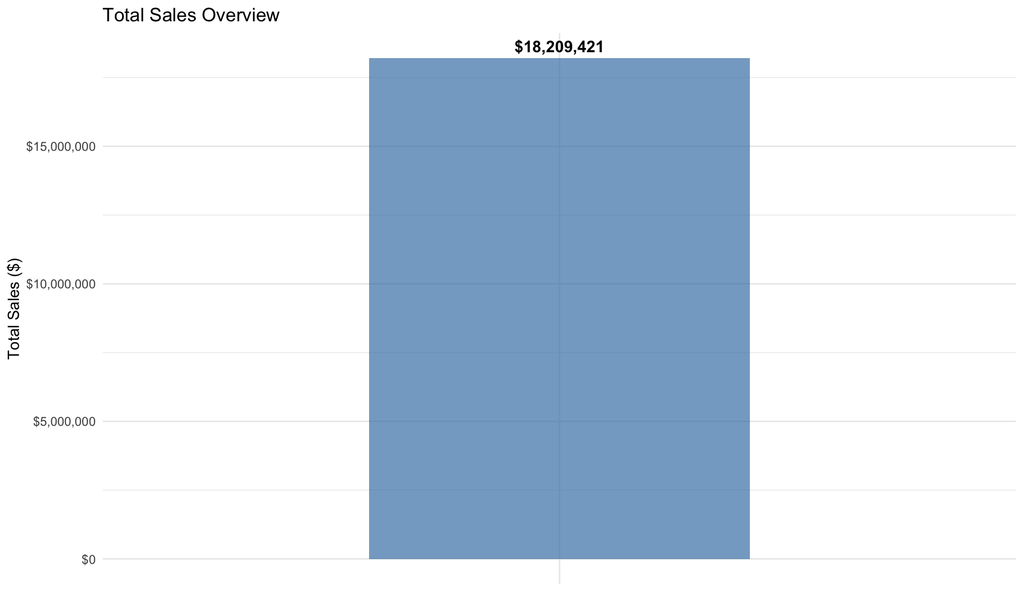

```r
# Calculate total sales
total_sales <- sum(sales_data$SALES, na.rm = TRUE)

# Create total sales visualization
p1 <- ggplot(data.frame(metric = "Total Sales", value = total_sales),
             aes(x = metric, y = value)) +
  geom_bar(stat = "identity", fill = "steelblue", alpha = 0.7, width = 0.5) +
  geom_text(aes(label = dollar_format()(value)),
            vjust = -0.5, size = 4, fontface = "bold") +
  labs(title = "Total Sales Overview",
       x = "",
       y = "Total Sales ($)") +
  theme_minimal() +
  theme(panel.background = element_rect(fill = "white", color = NA),
        plot.background = element_rect(fill = "white", color = NA),
        axis.text.x = element_blank(),
        axis.ticks.x = element_blank()) +
  scale_y_continuous(labels = dollar_format())

print(p1)
```

```r
cat("Total Sales:", dollar_format()(total_sales), "\n")
```

```
## Total Sales: $18,209,421
```

## 2. Sales by Years

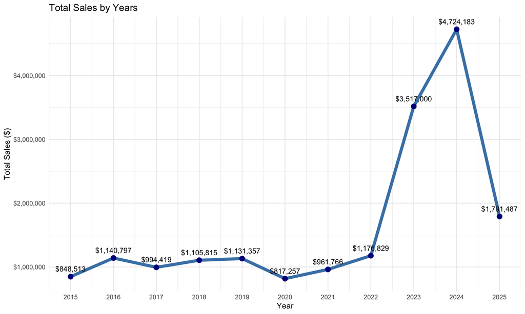

```r
# Calculate sales by year
sales_by_year <- sales_data %>%
  group_by(Year) %>%
  summarise(Total_Sales = sum(SALES, na.rm = TRUE), .groups = 'drop')

# Create sales by years visualization
p2 <- ggplot(sales_by_year, aes(x = Year, y = Total_Sales)) +
  geom_line(color = "steelblue", linewidth = 2) +
  geom_point(color = "darkblue", size = 3) +
  geom_text(aes(label = dollar_format()(Total_Sales)),
            vjust = -1, size = 3.5) +
  labs(title = "Total Sales by Years",
       x = "Year",
       y = "Total Sales ($)") +
  theme_minimal() +
  theme(panel.background = element_rect(fill = "white", color = NA),
        plot.background = element_rect(fill = "white", color = NA)) +
  scale_y_continuous(labels = dollar_format()) +
  scale_x_continuous(breaks = unique(sales_by_year$Year))

print(p2)
```

```r
# Display sales by year data
print(sales_by_year)
```

```
## # A tibble: 11 × 2
##     Year Total_Sales
##    <dbl>       <dbl>
##  1  2015     848513.
##  2  2016    1140797.
##  3  2017     994419.
##  4  2018    1105815.
##  5  2019    1131357.
##  6  2020     817257.
##  7  2021     961766.
##  8  2022    1176829.
##  9  2023    3517000.
## 10  2024    4724183.
## 11  2025    1791487.
```

## 3. Orders by Years

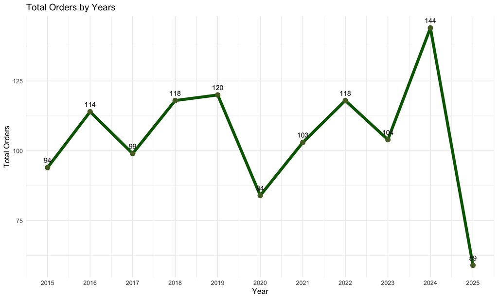

```r
# Calculate orders by year
orders_by_year <- sales_data %>%
  group_by(Year) %>%
  summarise(Total_Orders = n_distinct(ORDERNUMBER), .groups = 'drop')

# Create orders by years visualization
p3 <- ggplot(orders_by_year, aes(x = Year, y = Total_Orders)) +
  geom_line(color = "darkgreen", linewidth = 2) +
  geom_point(color = "darkolivegreen", size = 3) +
  geom_text(aes(label = comma_format()(Total_Orders)),
            vjust = -1, size = 3.5) +
  labs(title = "Total Orders by Years",
       x = "Year",
       y = "Total Orders") +
  theme_minimal() +
  theme(panel.background = element_rect(fill = "white", color = NA),
        plot.background = element_rect(fill = "white", color = NA)) +
  scale_y_continuous(labels = comma_format()) +
  scale_x_continuous(breaks = unique(orders_by_year$Year))

print(p3)
```

```r
# Display orders by year data
print(orders_by_year)
```

```
## # A tibble: 11 × 2
##     Year Total_Orders
##    <dbl>        <int>
##  1  2015           94
##  2  2016          114
##  3  2017           99
##  4  2018          118
##  5  2019          120
##  6  2020           84
##  7  2021          103
##  8  2022          118
##  9  2023          104
## 10  2024          144
## 11  2025           59
```

## 4. Total Quantity Overview

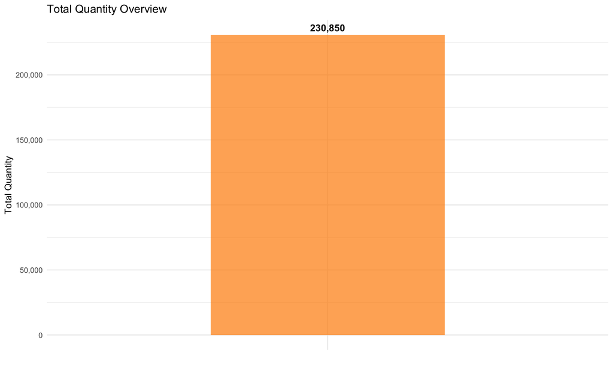

```r
# Calculate total quantity
total_quantity <- sum(sales_data$QUANTITYORDERED, na.rm = TRUE)

# Create total quantity visualization
p4 <- ggplot(data.frame(metric = "Total Quantity", value = total_quantity),
             aes(x = metric, y = value)) +
  geom_bar(stat = "identity", fill = "darkorange", alpha = 0.7, width = 0.5) +
  geom_text(aes(label = comma_format()(value)),
            vjust = -0.5, size = 4, fontface = "bold") +
  labs(title = "Total Quantity Overview",
       x = "",
       y = "Total Quantity") +
  theme_minimal() +
  theme(panel.background = element_rect(fill = "white", color = NA),
        plot.background = element_rect(fill = "white", color = NA),
        axis.text.x = element_blank(),
        axis.ticks.x = element_blank()) +
  scale_y_continuous(labels = comma_format())

print(p4)
```

```r
cat("Total Quantity:", total_quantity, "\n")
```

```
## Total Quantity: 230850
```

## 5. Quantity by Years

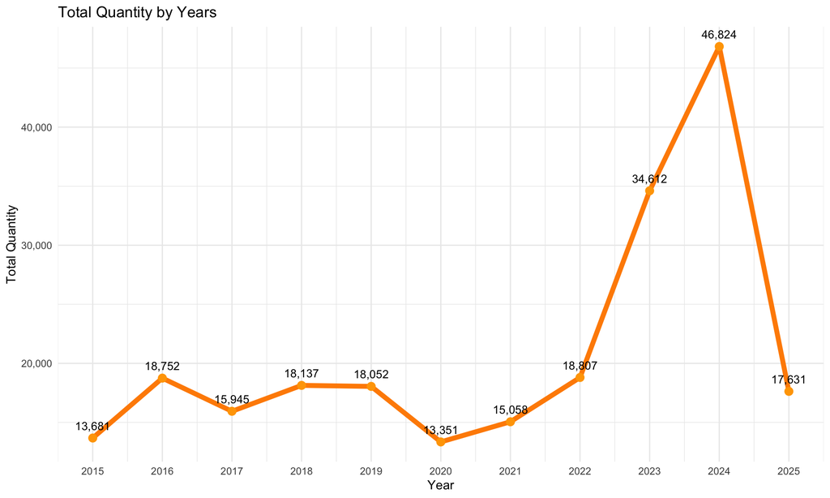

```r
# Calculate quantity by year
quantity_by_year <- sales_data %>%
  group_by(Year) %>%
  summarise(Total_Quantity = sum(QUANTITYORDERED, na.rm = TRUE), .groups = 'drop')

# Create quantity by years visualization
p5 <- ggplot(quantity_by_year, aes(x = Year, y = Total_Quantity)) +
  geom_line(color = "darkorange", linewidth = 2) +
  geom_point(color = "orange", size = 3) +
  geom_text(aes(label = comma_format()(Total_Quantity)),
            vjust = -1, size = 3.5) +
  labs(title = "Total Quantity by Years",
       x = "Year",
       y = "Total Quantity") +
  theme_minimal() +
  theme(panel.background = element_rect(fill = "white", color = NA),
        plot.background = element_rect(fill = "white", color = NA)) +
  scale_y_continuous(labels = comma_format()) +
  scale_x_continuous(breaks = unique(quantity_by_year$Year))

print(p5)
```

```r
# Display quantity by year data
print(quantity_by_year)
```

```
## # A tibble: 11 × 2
##     Year Total_Quantity
##    <dbl>          <dbl>
##  1  2015          13681
##  2  2016          18752
##  3  2017          15945
##  4  2018          18137
##  5  2019          18052
##  6  2020          13351
##  7  2021          15058
##  8  2022          18807
##  9  2023          34612
## 10  2024          46824
## 11  2025          17631
```

## 6. Quantity by Months

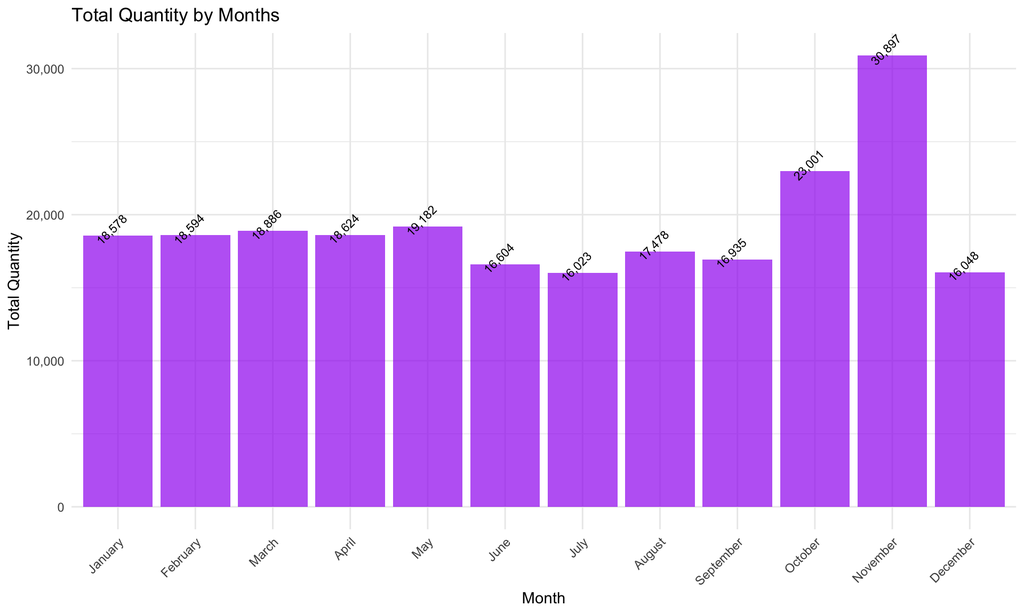

```r
# Calculate quantity by month
quantity_by_month <- sales_data %>%
  group_by(Month_Name) %>%
  summarise(Total_Quantity = sum(QUANTITYORDERED, na.rm = TRUE), .groups = 'drop') %>%
  mutate(Month_Name = factor(Month_Name, levels = month.name))

# Create quantity by months visualization
p6 <- ggplot(quantity_by_month, aes(x = Month_Name, y = Total_Quantity)) +
  geom_bar(stat = "identity", fill = "purple", alpha = 0.7) +
  geom_text(aes(label = comma_format()(Total_Quantity)),
            vjust = -0.5, size = 3, angle = 45) +
  labs(title = "Total Quantity by Months",
       x = "Month",
       y = "Total Quantity") +
  theme_minimal() +
  theme(panel.background = element_rect(fill = "white", color = NA),
        plot.background = element_rect(fill = "white", color = NA),
        axis.text.x = element_text(angle = 45, hjust = 1)) +
  scale_y_continuous(labels = comma_format())

print(p6)
```

```r
# Display quantity by month data
print(quantity_by_month)
```

```
## # A tibble: 12 × 2
##    Month_Name Total_Quantity
##    <fct>               <dbl>
##  1 April               18624
##  2 August              17478
##  3 December            16048
##  4 February            18594
##  5 January             18578
##  6 July                16023
##  7 June                16604
##  8 March               18886
##  9 May                 19182
## 10 November            30897
## 11 October             23001
## 12 September           16935
```

# Summary and Analysis

## Key Performance Indicators

```r
# Calculate key performance indicators
cat("=== KEY PERFORMANCE INDICATORS ===\n")
```

```
## === KEY PERFORMANCE INDICATORS ===
```

```r
cat("Total Sales:", dollar_format()(total_sales), "\n")
```

```
## Total Sales: $18,209,421
```

```r
cat("Total Quantity:", total_quantity, "\n")
```

```
## Total Quantity: 230850
```

## Year-over-Year Analysis

```r
cat("\n=== YEAR-OVER-YEAR ANALYSIS ===\n")
```

```
##
## === YEAR-OVER-YEAR ANALYSIS ===
```

```r
for (i in 1:nrow(sales_by_year)) {
  year <- sales_by_year$Year[i]
  sales <- sales_by_year$Total_Sales[i]
  orders <- orders_by_year$Total_Orders[i]
  quantity <- quantity_by_year$Total_Quantity[i]

  cat("Year", year, ":\n")
  cat("  - Sales:", dollar_format()(sales), "\n")
  cat("  - Orders:", orders, "\n")
  cat("  - Quantity:", quantity, "\n")
  cat("\n")
}
```

```
## Year 2015 :
##   - Sales: $848,513
##   - Orders: 94
##   - Quantity: 13681
##
## Year 2016 :
##   - Sales: $1,140,797
##   - Orders: 114
##   - Quantity: 18752
##
## Year 2017 :
##   - Sales: $994,419
##   - Orders: 99
##   - Quantity: 15945
##
## Year 2018 :
##   - Sales: $1,105,815
##   - Orders: 118
##   - Quantity: 18137
##
## Year 2019 :
##   - Sales: $1,131,357
##   - Orders: 120
##   - Quantity: 18052
##
## Year 2020 :
##   - Sales: $817,257
##   - Orders: 84
##   - Quantity: 13351
##
## Year 2021 :
##   - Sales: $961,766
##   - Orders: 103
##   - Quantity: 15058
##
## Year 2022 :
##   - Sales: $1,176,829
##   - Orders: 118
##   - Quantity: 18807
##
## Year 2023 :
##   - Sales: $3,517,000
##   - Orders: 104
##   - Quantity: 34612
##
## Year 2024 :
##   - Sales: $4,724,183
##   - Orders: 144
##   - Quantity: 46824
##
## Year 2025 :
##   - Sales: $1,791,487
##   - Orders: 59
##   - Quantity: 17631
```

## Monthly Patterns

```r
cat("=== MONTHLY QUANTITY PATTERNS ===\n")
```

```
## === MONTHLY QUANTITY PATTERNS ===
```

```r
for (i in 1:nrow(quantity_by_month)) {
  month <- quantity_by_month$Month_Name[i]
  quantity <- quantity_by_month$Total_Quantity[i]
  cat("-", month, ":", quantity, "units\n")
}
```

```
## - 4 : 18624 units
## - 8 : 17478 units
## - 12 : 16048 units
## - 2 : 18594 units
## - 1 : 18578 units
## - 7 : 16023 units
## - 6 : 16604 units
## - 3 : 18886 units
## - 5 : 19182 units
## - 11 : 30897 units
## - 10 : 23001 units
## - 9 : 16935 units
```

# Business Insights

## Key Findings

1. **Sales Performance**: The dashboard shows comprehensive sales performance across multiple metrics.
2. **Temporal Trends**: Analysis reveals sales, order, and quantity trends over time periods.
3. **Seasonal Patterns**: Monthly analysis provides insights into seasonal variations in product quantity.
4. **Operational Metrics**: Key performance indicators help understand business efficiency.

## Recommendations

1. **Performance Monitoring**: Use these visualizations for regular performance monitoring.
2. **Trend Analysis**: Monitor year-over-year trends to identify growth patterns.
3. **Seasonal Planning**: Use monthly patterns for inventory and resource planning.
4. **Goal Setting**: Use historical data to set realistic targets for future periods.

## Dashboard Usage

This dashboard provides: - **Executive Summary**: High-level KPIs for management reporting - **Trend Analysis**: Time-series visualizations for trend identification - **Operational Insights**: Detailed metrics for operational decision-making - **Performance Tracking**: Tools for monitoring business performance

The visualizations are designed with white backgrounds for professional presentation and can be easily integrated into reports and presentations.

# Combined Dashboard

## Comprehensive Dashboard View

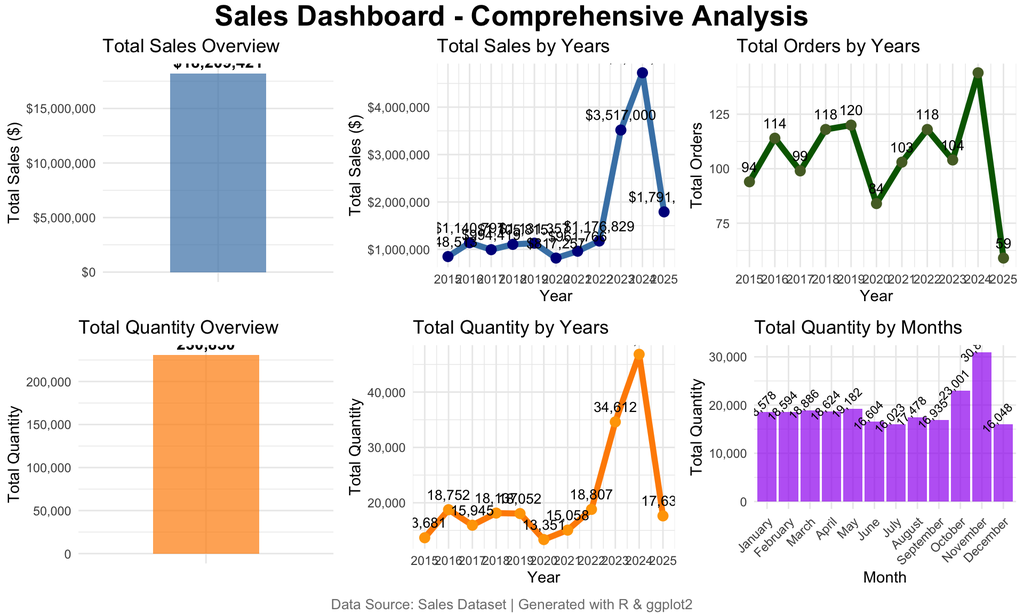

```r
# Create a combined dashboard layout
combined_dashboard <- grid.arrange(
  p1, p2, p3,  # Top row: Total Sales, Sales by Years, Orders by Years
  p4, p5, p6,  # Bottom row: Total Quantity, Quantity by Years, Quantity by Months
  ncol = 3,
  nrow = 2,
  top = textGrob("Sales Dashboard - Comprehensive Analysis",
                 gp = gpar(fontsize = 20, fontface = "bold")),
  bottom = textGrob("Data Source: Sales Dataset | Generated with R & ggplot2",
                    gp = gpar(fontsize = 10, col = "gray50"))
)
```

```r
print(combined_dashboard)
```

This combined dashboard provides a comprehensive overview of all key sales metrics in a single view, similar to professional business intelligence dashboards. The layout is organized in a 2x3 grid with:

- **Top Row**: Total Sales, Sales by Years, Orders by Years
- **Bottom Row**: Total Quantity, Quantity by Years, Quantity by Months

The dashboard maintains consistent styling and white backgrounds for professional presentation.